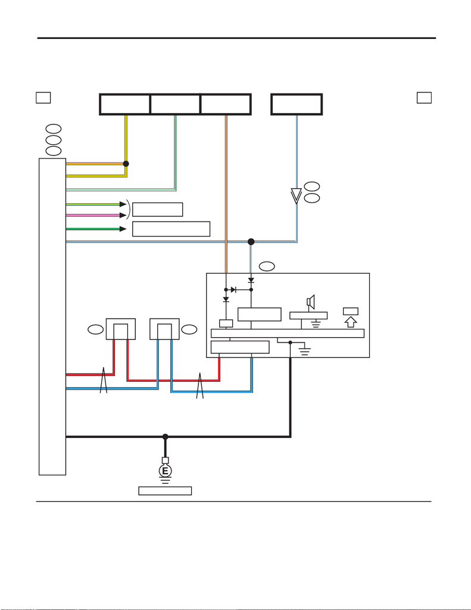

WI-275

Keyless Access System

WIRING SYSTEM

29.Keyless Access System

A: WIRING DIAGRAM

1. ENGINE TYPE FA

WI-44474

i232 i233

1a 1a

i229

B551

I/F

1

3

Y/R

Y/R

A32

A:

B280

C:

i84

D:

i171

Y/RA4

W/G

W/G

D1

BR/W

W/L

W/LC6

RC27

33

GD18

G/YC4

W/L

BC1

i10

R

32L

38B

LC35

BR/W20

40

1

R

1

R

1

L

1

L

J/CJ/C

P/LD8

W/L W/L

B

TFT

COMBINATION

METER

FB-18

F/B FUSE NO. 7

(B)

FB-12

F/B FUSE NO. 2

(IG)

BODY INTEGRATED

UNIT

FB-6

F/B FUSE NO. 3

(B)

FB-29

F/B FUSE NO. 31

(ACC)

SPEAKER

DRIVE CIRCUIT

CAN TRANSCEIVER &

RECEIVER

MICRO COMPUTER

REF. TO INTERIOR

LIGHT SYSTEM [b]

POWER SUPPLY

CIRCUIT

: TERMINAL No. OPTIONAL ARRANGEMENT

REF. TO TURN SIGNAL LIGHT &

HAZARD LIGHT SYSTEM [b]

REF. TO GND [e]

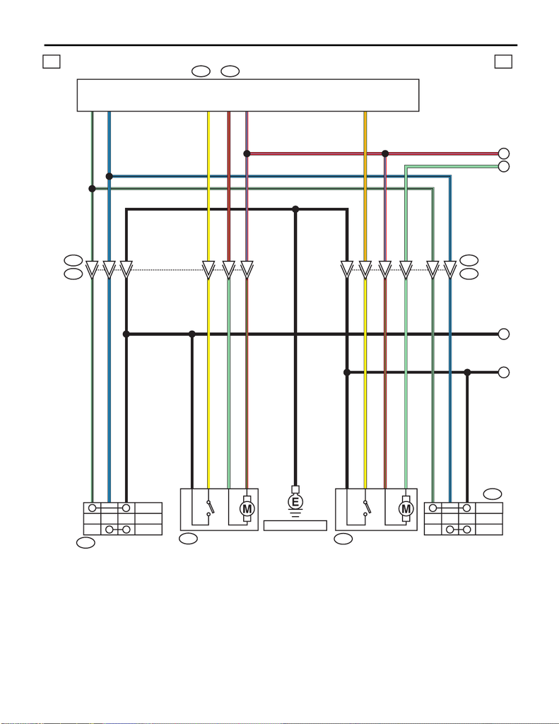

WI-276

Keyless Access System

WIRING SYSTEM

WI-44475

1b 1b

15

16

19

18

17

3

19

17

18

15

16

3

D7A:

A

B

C

D

D72

D18

D125

C:

i84

D:

i171

B

L/B

LG/B

B

B

B

i101

D84

LOCK

OFF

UNLOCK

4

1

8

7

A9

A1

A3

C12

D2

C23

D83

i76

L/B

LG/B

BB

Y

R/G

R/L

Y

LG

R/G

Y

LG

R/G

Y

D4R/G

R/L

R/L

LG

Y/RY/R

R/L

B

Y

R/G

B

Y

R/G

B

7

4

8

LG/B

4

L/B

2

B

5

LG

LG

1

LG

L/B

LG/B

C20L/B

C9LG/B

LG/BLG/B

L/B L/B

LOCK

OFF

UNLOCK

B B

PASSENGER'S

DOOR LOCK SWITCH

FRONT DOOR LOCK

ACTUATOR RH

FRONT DOOR LOCK

ACTUATOR LH

POWER WINDOW

MAIN SWITCH

(DOOR LOCK SWITCH)

BODY INTEGRATED UNIT

REF. TO GND [j]

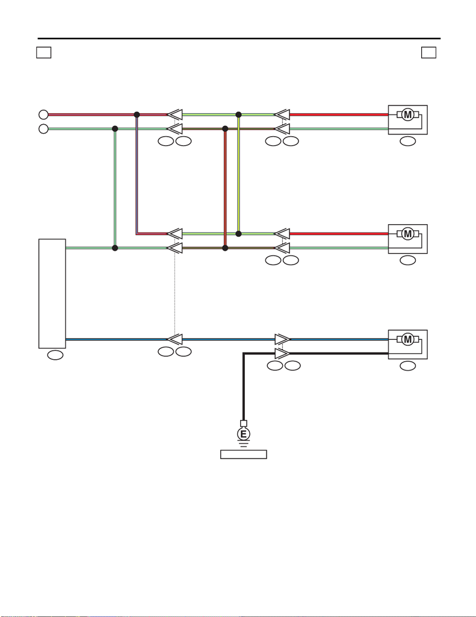

WI-277

Keyless Access System

WIRING SYSTEM

REF. TO GND [h]

WI-44476

1c 1c

10

2

13

14

11

A

B

R186

D32

D26

R10 D22

i102 R167

R13 D28

i53 R98

R24 R60

D: i171

B/L

BB2

1D7

R/L

R

LG 1

4

R

LG 1

4

R/GR/G

LG

LG/Y LG/Y

R

LGLG

R/L

B/L

R/GR/G

LG

LG/Y LG/Y

R

LG

R/L

B/L

D3 LG

LG

R/G

B/L

B

8

7

8

7

6

12

LG/Y

BODY INTEGRATED

UNIT

REAR DOOR LOCK

ACTUATOR LH

REAR DOOR LOCK

ACTUATOR RH

TRUNK LID LOCK

ACTUATOR

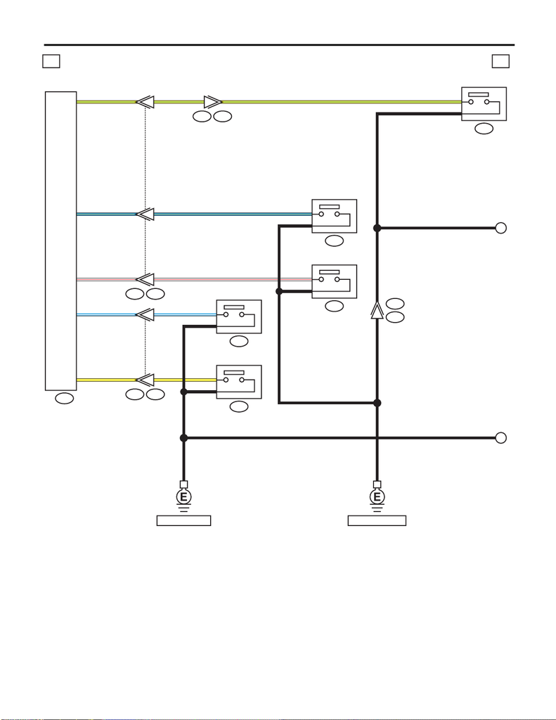

WI-278

Keyless Access System

WIRING SYSTEM

WI-44477

1d 1d

15

16

15

16

17

1

6

i84C:

R22

R9

F

i2 R339

R16

R12

i195 R382

R186

R24 R60

R24

R60

1

3

1

3

B

B

BB

B

E

B

Y/W Y/W

L/W L/W

C24

C14

B

B

B

1

3

1

3

W/R W/R

L/O L/O

C25

C13

C33

B

B

W/R

L/O

Y/L

B

3

2

Y/LY/L Y/L

BB

TRUNK LID LOCK

SWITCH

FRONT DOOR

SWITCH RH

REAR DOOR

SWITCH RH

FRONT DOOR

SWITCH LH

BODY

INTEGRATED UNIT

REAR DOOR

SWITCH LH

REF. TO GND [h] REF. TO GND [f]

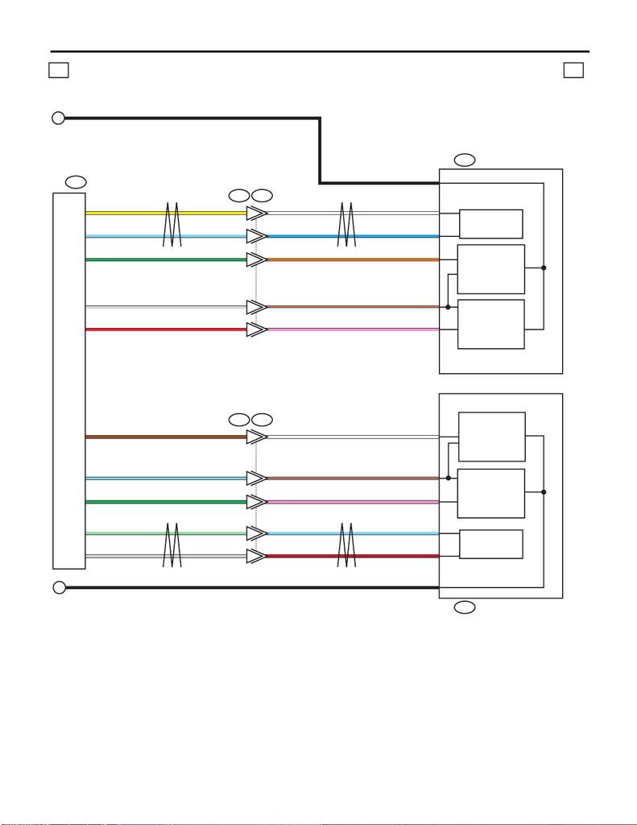

WI-279

Keyless Access System

WIRING SYSTEM

WI-44478

1e 1e

6

2

1

4

5

6

5

2

1

4

C11

C

D

B574C:

D56

B30 D1

D66

C10

C8

C23

C22

C20

C19

C12

C13 GR

LG

G

SB

BR

R

G

SB

Y

GR

LG

G

SB

BR

R

G

SB

Y

R/B

SB

LG/R

W

P

Y/R

L

W

P

C21 GR GR LG/R

B101 D11

2B

B

6W

3L

1Y/R

5LG/R

4P

4W

5LG/R

1P

6SB

3R/B

2BB

OUTER HANDLE LH

OUTER HANDLE RH

KEYLESS ACCESS CM

TOUCH SENSOR

(LOCK)

ANTENNA

TOUCH SENSOR

(LOCK)

TOUCH SENSOR

(UNLOCK)

ANTENNA

TOUCH SENSOR

(UNLOCK)

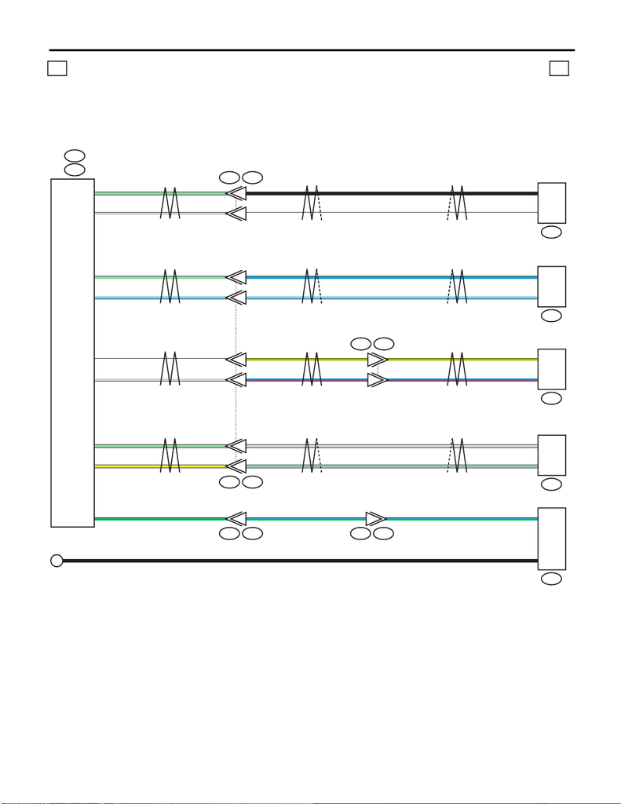

WI-280

Keyless Access System

WIRING SYSTEM

WI-44479

1f 1f

R299

AD12

R82R81

R5B92

AD11B579

R1B97 R60R24

R297

B573B:

B574C:

R298

WB10

GRB11

W

GR

Y/L

L/R

1

3

LG

Y

LG

Y

GRB1

B2

Y/L

L/R

GR

GR/G

3

8

GR/G

1

6

LG

SB

LG

SB

L/G

SB

L/G

SB

2

7

2

1

LGC3

GR

LG

GRC2

B8

B9

3

1B

W

B

W

8

7

2

1

R294

G

B

G G/L G/LB27

G/L

B

10 7

2

1

3

1

E

KEYLESS ACCESS

INTERIOR ANTENNA

(FRONT)

KEYLESS ACCESS CM

KEYLESS ACCESS

INTERIOR ANTENNA

(REAR)

KEYLESS ACCESS

EXTERIOR ANTENNA

(REAR)

TRUNK OPENER SWITCH

KEYLESS ACCESS

INTERIOR ANTENNA

(CENTER)

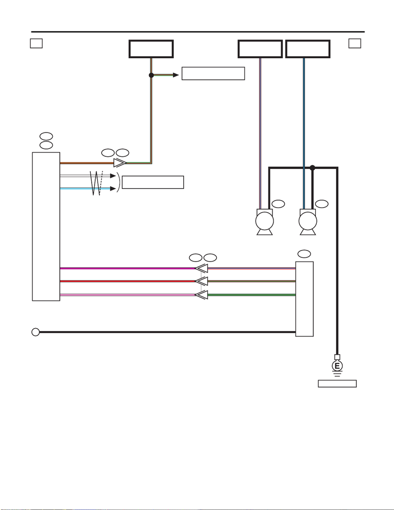

WI-281

Keyless Access System

WIRING SYSTEM

WI-44480

1g 1g

B23

F

R5

G/R

B28

BRC5

C15

C14

B573B:

B574C:

W

SB

G/R

1B

R296

V

R5

4B5

B17

R/L

R/G

P2B19 G/R

R/L

R/G

G/R

V

R

P

B

4

9

5

10

G/R

B92

F47F5

B1

B1

B

REF. TO GND [a]

B/L

B/L2

R/LR/L2

REF. TO ENGINE ELECTRICAL

SYSTEM [2a]

RECEIVER

FB-38

F/B FUSE NO. 12

(IG)

KEYLESS ACCESS CM

REF. TO CAN COMMUNICATION

SYSTEM [b]

HORNHORN

MB-20

M/B FUSE NO. 9

MB-19

M/B FUSE NO. 9

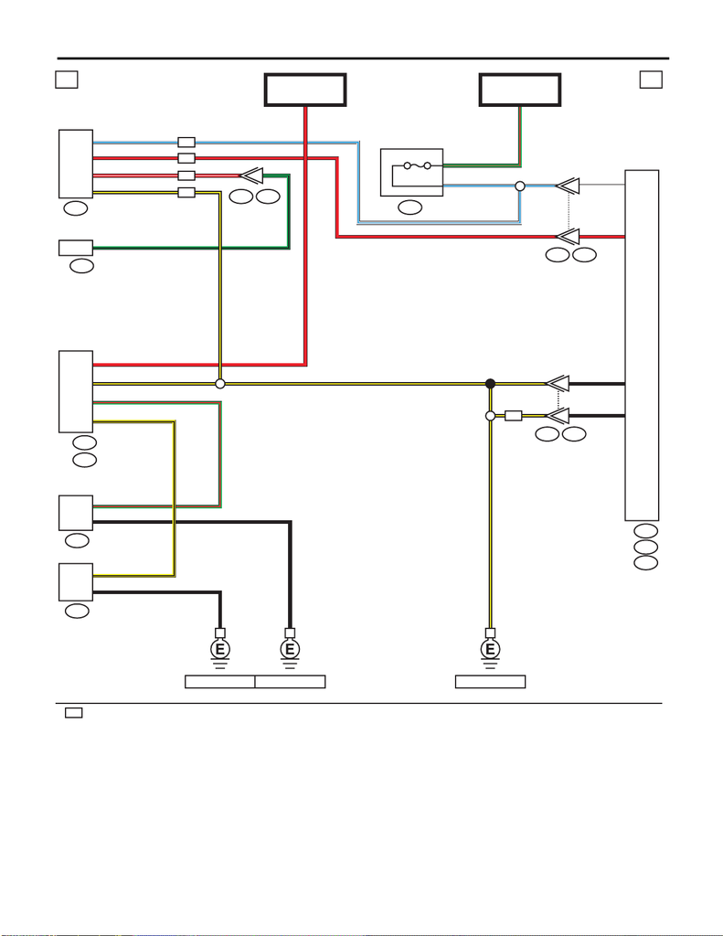

WI-282

Keyless Access System

WIRING SYSTEM

12

WI-44481

1h 1h

3

A: B280

B422

C: i84

A

B572

B

B573

G/R

25

G/R

10

B550

W

GR/L GR/L

GR/L

A2

RR C17

Y/B

A20

G/R

C10

B/Y B/Y

B/Y

B

B

A11

B15

A1

A24

1 GR/L

B575 B576

R

MB-35

SBF-8

(B)

:

C

B574

:

:

ID

2R

ID

4 R/W R/W G/B

ID

5

B: E158

B43 G/B

i13

3

2

B164

2

1

B

G/R

B

Y/B

B/Y

ID

ID

2

14

B22 E3

B

B/Y

B

REF. TO GND [e] REF. TO GND [c]REF. TO GND [b]

20

B575 B576

R

ID

FUSE HOLDER

7.5A

BODY INTEGRATED

UNIT

ID CODE BOX

ECM

TRUNK LID OPENER

SWITCH

KEYLESS BUZZER

KEYLESS

ACCESS CM

: WITH ID CODE BOX

MB-21

HORN RELAY

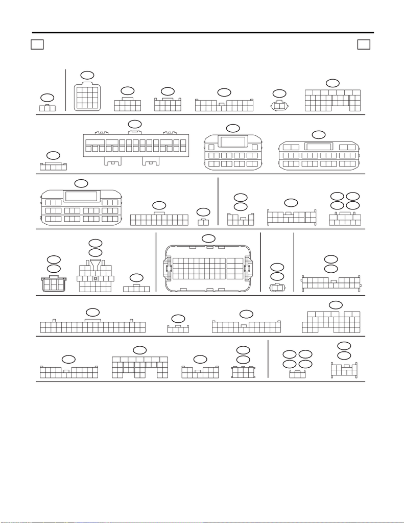

WI-283

Keyless Access System

WIRING SYSTEM

i229

12 345

6789

10 11 12

E158

(B)

79

10

85

23

11 12

6

19 21 222017

24

35 36

47 48

18

31 33 343229 30

43 45 464441 42

3412

15 1613 14

27 2825 26

39 4037 38

B:

WI-44482

1i 1i

i2

12345 6789

10 11 12 13 14 15 16 17 18 19 20

i233

i232

78

5

6

34

21

i10

11 12

9

10

7856341

2

15 1613 14 19

18

20

21 22 23 24 26

25

27 28 29 30 31 32 33 34 35 36 37 38 39 40

17

(GR)

B164

12

B280

18

2719 20 21 22

23

26

24

25

28 29 3332 3430 31

98

15

1413121110

17

16

1234567

A:

123

456789

10 11

12 13 14 15 16 17 18 19 20 21 22

B575

91

2

232221 262524201918

4

13

12

17

3

16

6

15

587

14

10 11

B550

(B)

11 12

34

13 14

56

15 16

78

17 18

10

9

12

B572A:

21

B579

D1

D11

321

87654

D7

123

89

10

4

11 12 13 14 15 16

56

7

A:

1

76589

10

342

D72

D32

D26

D18

D66

D56

3

4

2

1

56

D84

D83

19

18

20 21 22

1514131211

1

3

24

5

7

6

98

10

17

25

24

26 27 2823

16

D125

12345

(B)

F47

(B)

F5

12

3412 89

10 11

12 13 14 15 16 17 18 19 20 21 22 23 24

567

i53

i84C:

19

18

21

20

2322 24 25 26

17

1

23

4

56

27

28 29 30

31 32 33 34 35

798

151413121110 16

89

19 20

1234 567

10 11 12 13 14 15 16 17 18

i102

i171D:

19

18

20 21

22

23

26

24

25

27

28 29

30 31

98

15

1413121110

17

16

1234567

i195

123

R22R12

R9

R16

B92

91078

5

6

3421

B422

1

2

345

i13

(GR)

2143

(BR)

B22

AD12

12

3

4

5678

9

10 11 12

1413 15 16

B23

10

12345

6789

89

19 20

1234 567

10 11 12 13 14 15 16 17 18

B97

B573B:

17 18 19 20 21 22 23 24 25 26 27 28

567 89

10 11 12 13 14 15 16

12 34

B574C:

19 20 21 22 23 24 25 26 27 28 29 30

789

10 11 12 13 14 15 16 17 18

123 456

123

R13

R10

65

21

4

3

87

LIST OF CONNECTORS

FUSE HOLDER

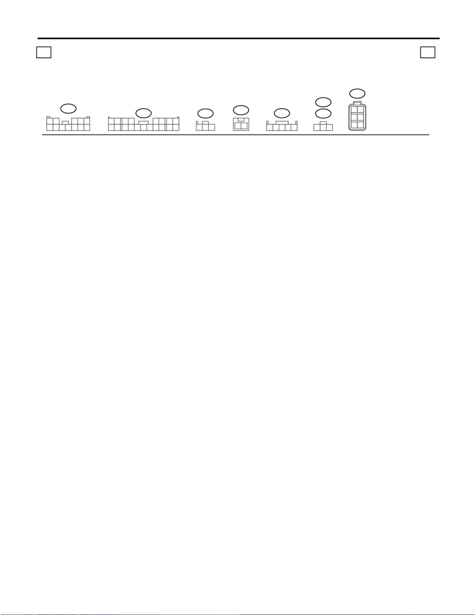

WI-284

Keyless Access System

WIRING SYSTEM

R60

12 345

6789

10 11 12

WI-44483

1j 1j

R296

3

421

5

R298

R297

123

R186

123

R294

21

(BR)

(B)

R82

1

9

234 5678

10 11 12 14 15 16 17 18 1913

R299

56

34

12

LIST OF CONNECTORS

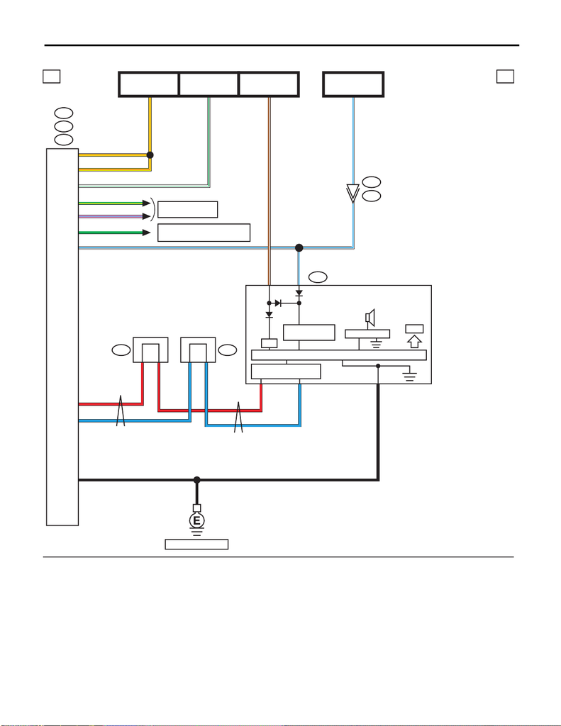

WI-285

Keyless Access System

WIRING SYSTEM

2. ENGINE TYPE EJ

WI-44484

2a 2a

i229

B551

I/F

1

3

Y/R

Y/R

A32

A:

B280

C:

i84

D:

i171

Y/RA4

W/G

W/G

D1

BR/W

W/L

W/LC6

RC27

33

GD18

G/YC4

W/L

BC1

i10

R

32L

38B

LC35

BR/W20

40

1

R

1

R

1

L

1

L

P/LD8

W/L W/L

B

i232 i233

J/C

J/C

TFT

COMBINATION

METER

FB-18

F/B FUSE NO. 7

(B)

FB-12

F/B FUSE NO. 2

(IG)

BODY INTEGRATED

UNIT

FB-6

F/B FUSE NO. 3

(B)

FB-29

F/B FUSE NO. 31

(ACC)

SPEAKER

DRIVE CIRCUIT

CAN TRANSCEIVER &

RECEIVER

MICRO COMPUTER

REF. TO INTERIOR

LIGHT SYSTEM [b]

POWER SUPPLY

CIRCUIT

: TERMINAL No. OPTIONAL ARRANGEMENT

REF. TO TURN SIGNAL LIGHT &

HAZARD LIGHT SYSTEM [b]

REF. TO GND [e]

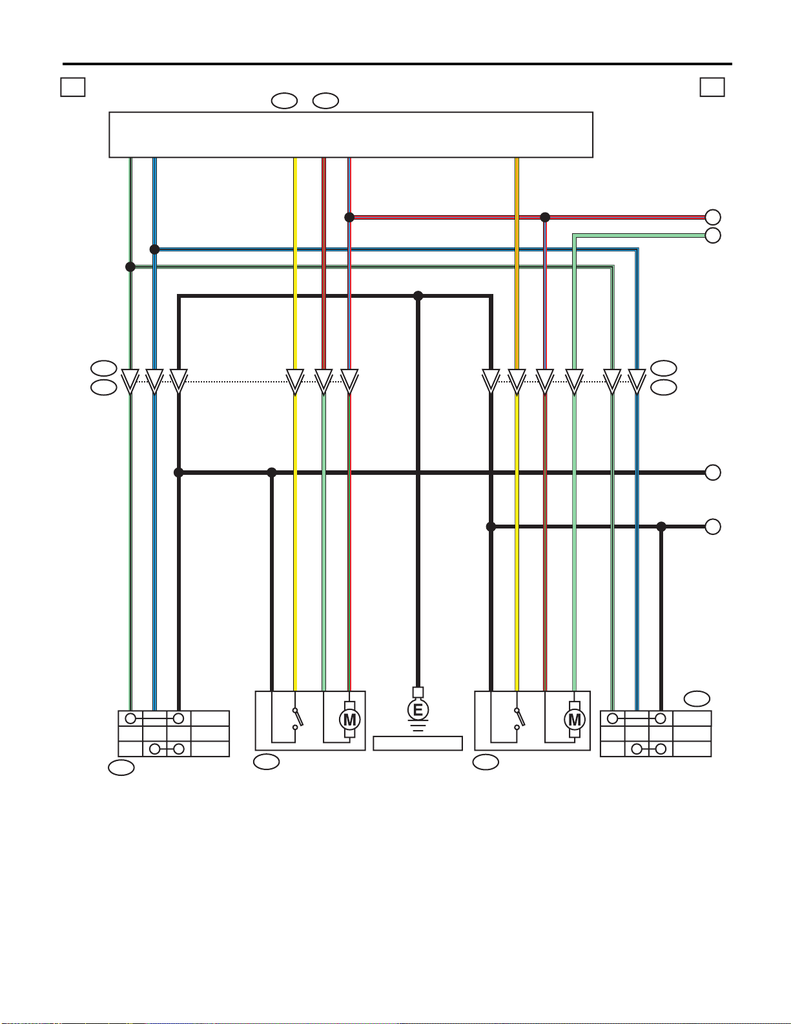

WI-286

Keyless Access System

WIRING SYSTEM

WI-44485

2b 2b

15

16

19

18

17

3

19

17

18

15

16

3

D7A:

A

B

C

D

D72

D18

D125

C:

i84

D:

i171

B

L/B

LG/B

B

B

B

i101

D84

LOCK

OFF

UNLOCK

4

1

8

7

A9

A1

A3

C12

D2

C23

D83

i76

L/B

LG/B

BB

Y

R/G

R/L

Y

LG

R/G

Y

LG

R/G

Y

D4R/G

R/L

R/L

LG

Y/RY/R

R/L

B

Y

R/G

B

Y

R/G

B

7

4

8

LG/B

4

L/B

2

B

5

LG

LG

1

LG

L/B

LG/B

C20L/B

C9LG/B

LG/BLG/B

L/B L/B

LOCK

OFF

UNLOCK

B B

PASSENGER'S

DOOR LOCK SWITCH

FRONT DOOR LOCK

ACTUATOR RH

FRONT DOOR LOCK

ACTUATOR LH

POWER WINDOW

MAIN SWITCH

(DOOR LOCK SWITCH)

BODY INTEGRATED UNIT

REF. TO GND [j]

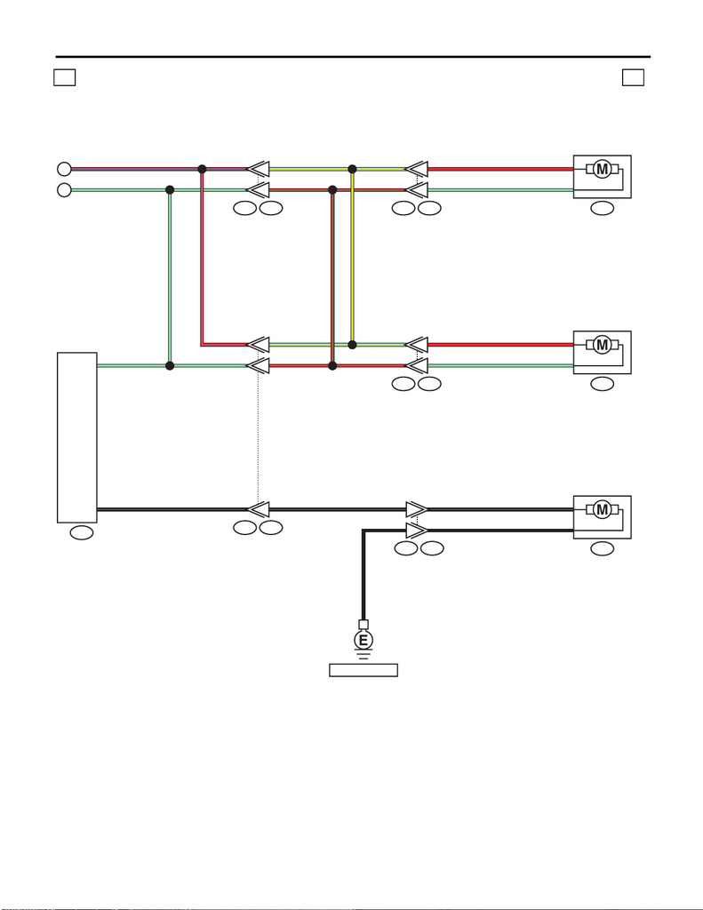

WI-287

Keyless Access System

WIRING SYSTEM

REF. TO GND [h]

WI-44486

2c 2c

10

2

13

14

11

A

B

R186

D32

D26

R10 D22

i102 R167

R13 D28

i53 R98

R24 R60

D: i171

B/L

BB2

1D7

R/L

R

LG 1

4

R

LG 1

4

R/GR/G

LG

LG/Y LG/Y

R

LGLG

R/L

B/L

R/GR/G

LG

LG/Y LG/Y

R

LG

R/L

B/L

D3 LG

LG

R/G

B/L

B

8

7

8

7

6

12

LG/Y

BODY INTEGRATED

UNIT

REAR DOOR LOCK

ACTUATOR LH

REAR DOOR LOCK

ACTUATOR RH

TRUNK LID LOCK

ACTUATOR

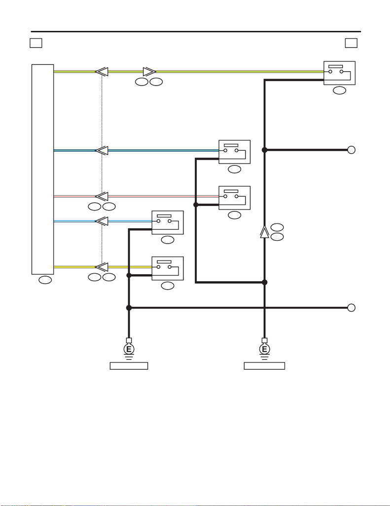

WI-288

Keyless Access System

WIRING SYSTEM

WI-44487

2d 2d

15

16

15

16

17

1

6

i84C:

R22

R9

F

i2 R339

R16

R12

i195 R382

R186

R24 R60

R24

R60

1

3

1

3

B

B

BB

B

E

B

Y/W Y/W

L/W L/W

C24

C14

B

B

B

1

3

1

3

W/R W/R

L/O L/O

C25

C13

C33

B

B

W/R

L/O

Y/L

B

3

2

Y/LY/L Y/L

BB

TRUNK LID LOCK

SWITCH

FRONT DOOR

SWITCH RH

REAR DOOR

SWITCH RH

FRONT DOOR

SWITCH LH

BODY

INTEGRATED UNIT

REAR DOOR

SWITCH LH

REF. TO GND [h] REF. TO GND [f]

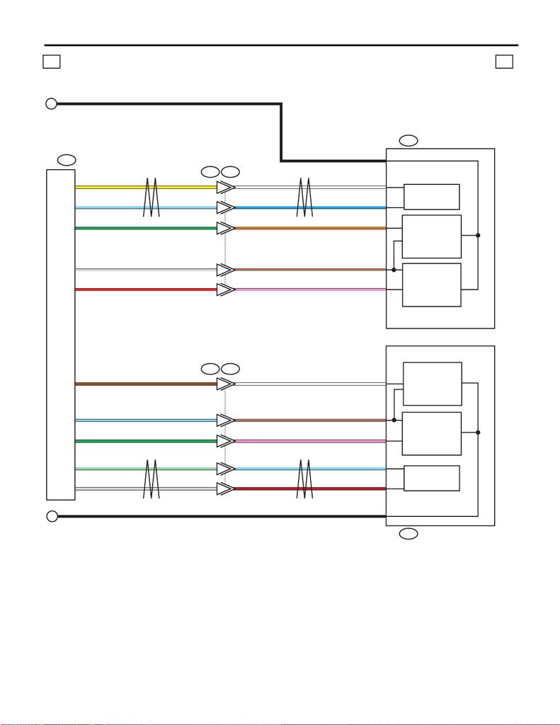

WI-289

Keyless Access System

WIRING SYSTEM

WI-44488

2e 2e

6

2

1

4

5

6

5

2

1

4

C11

C

D

B574C:

D56

B30 D1

D66

C10

C8

C23

C22

C20

C19

C12

C13 GR

LG

G

SB

BR

R

G

SB

Y

GR

LG

G

SB

BR

R

G

SB

Y

R/B

SB

LG/R

W

P

Y/R

L

W

P

C21 GR GR LG/R

B101 D11

2B

B

6W

3L

1Y/R

5LG/R

4P

4W

5LG/R

1P

6SB

3R/B

2BB

OUTER HANDLE LH

OUTER HANDLE RH

KEYLESS ACCESS CM

TOUCH SENSOR

(LOCK)

ANTENNA

TOUCH SENSOR

(LOCK)

TOUCH SENSOR

(UNLOCK)

ANTENNA

TOUCH SENSOR

(UNLOCK)

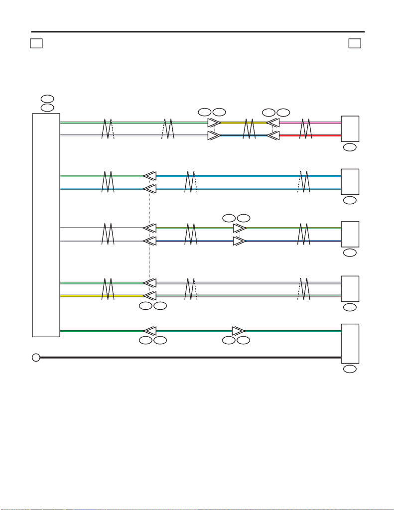

WI-290

Keyless Access System

WIRING SYSTEM

WI-44489

2f 2f

R299

AD12

R82R81

R5B92

R297

B573B:

B574C:

R298

WB10

GRB11

W

GR

Y/L

L/R

1

3

LG

Y

LG

Y

GRB1

B2

Y/L

L/R

GR

GR/G

3

8

B575B576

8

22

GR/G

1

6

LG

SB

LG

SB

L/G

SB

L/G

SB

2

7

LGC3

GR

LG

GR

Y/B

L/BC2

B8

B9

3

1P

R

8

7

2

1

3

1

R1B97 R60R24

R294

10 7

B

G/L G/L

G/L

B

E

GG 2

1

B27

AD13B4

9

3

KEYLESS ACCESS

INTERIOR ANTENNA

(FRONT)

KEYLESS ACCESS CM

KEYLESS ACCESS

INTERIOR ANTENNA

(REAR)

KEYLESS ACCESS

EXTERIOR ANTENNA

(REAR)

KEYLESS ACCESS

INTERIOR ANTENNA

(CENTER)

TRUNK OPENER

SWITCH

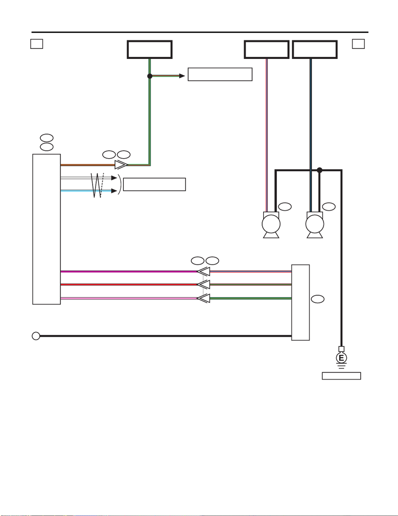

WI-291

Keyless Access System

WIRING SYSTEM

WI-44490

2g 2g

B23

F

R5

G/R

B28

BRC5

C15

C14

B573B:

B574C:

W

SB

G/R

1B

R296

V

R5

4B5

B17

R/L

R/G

P2B19 G/R

R/L

R/G

G/R

V

R

P

B

4

9

5

10

G/R

B92

F47F5

B1

B1

B

REF. TO GND [a]

B/L

B/L2

R/LR/L2

REF. TO ENGINE ELECTRICAL

SYSTEM [4a]

RECEIVER

FB-38

F/B FUSE NO. 12

(IG)

KEYLESS ACCESS CM

REF. TO CAN COMMUNICATION

SYSTEM [b]

HORNHORN

MB-20

M/B FUSE NO. 9

MB-19

M/B FUSE NO. 9

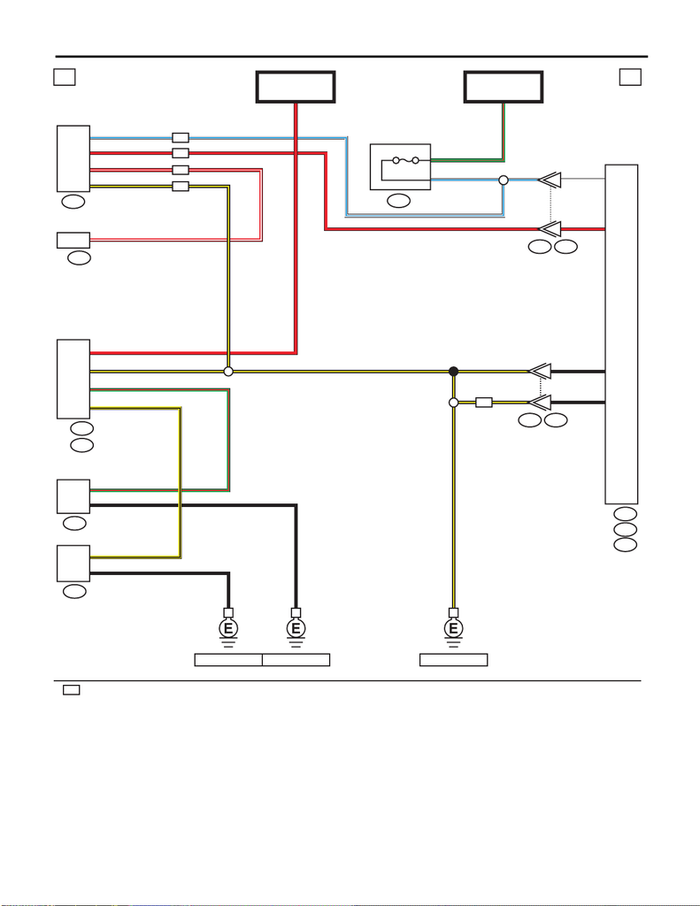

WI-292

Keyless Access System

WIRING SYSTEM

12

WI-44491

2h 2h

3

A: B280

B422

C: i84

A

B572

B

B573

G/R

26

G/R

11

B550

W

GR/L GR/L

GR/L

A2

RR C17

Y/B

A20

G/R

C10

B/Y B/Y

B/Y

B

B

A11

B15

A1

A24

1 GR/L

B575 B576

R

MB-35

SBF-8

(B)

:

C

B574

:

:

ID

2R

ID

4 R/W

ID

5

B: B135

B25 R/W

i13

3

2

B164

2

1

B

G/R

B

Y/B

B/Y

ID

ID

2

B

B/Y

B

REF. TO GND [e] REF. TO GND [c]REF. TO GND [b]

20

B575 B576

R

ID

FUSE HOLDER

7.5A

BODY INTEGRATED

UNIT

ID CODE BOX

ECM

TRUNK LID OPENER

SWITCH

KEYLESS BUZZER

KEYLESS

ACCESS CM

: WITH ID CODE BOX

MB-21

HORN RELAY

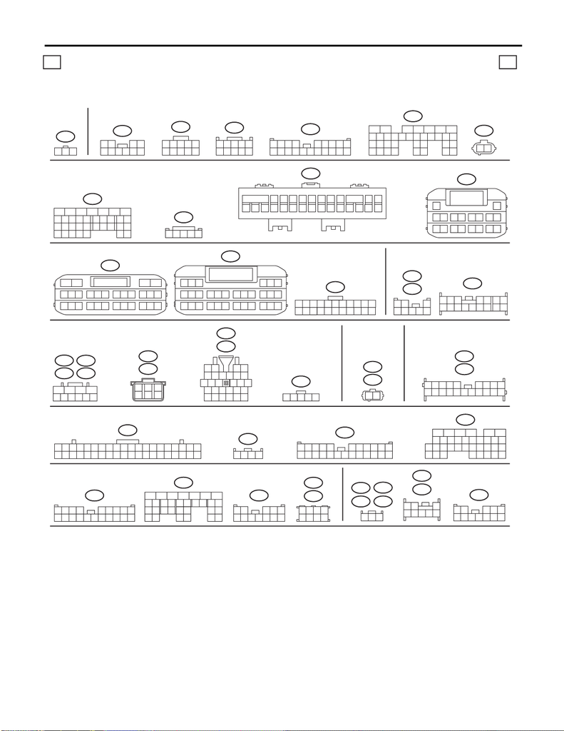

WI-293

Keyless Access System

WIRING SYSTEM

i229

R60

12 345

6789

10 11 12

12 345

6789

10 11 12

i2

12345 6789

10 11 12 13 14 15 16 17 18 19 20

B135B:

5672134

29

10 11 12 13 14 15

2524

16

30

98

17 18 19

20

28

21 22 23

3231

26 27

33 34 35

WI-44492

2i 2i

i233

i232

78

5

6

34

21

i10

11 12

9

10

7856341

2

15 1613 14 19

18

20

21 22 23 24 26

25

27 28 29 30 31 32 33 34 35 36 37 38 39 40

17

(GR)

B164

12

B280

18

2719 20 21 22

23

26

24

25

28 29 3332 3430 31

98

15

1413121110

17

16

1234567

A:

11 12

34

13 14

56

15 16

78

17 18

10

9

12

B572A:

D1

D11

321

87654

D7

123

89

10

4

11 12 13 14 15 16

56

7

A:

1

76589

10

342

D72

D32

D26

D18

D66

D56

3

4

2

1

56

D84

D83

19

18

20 21 22

1514131211

1

3

24

5

7

6

98

10

17

25

24

26 27 2823

16

D125

12345

(B)

F47

(B)

F5

12

3412 89

10 11

12 13 14 15 16 17 18 19 20 21 22 23 24

567

i53

i84C:

19

18

21

20

2322 24 25 26

17

1

23

4

56

27

28 29 30

31 32 33 34 35

798

151413121110 16

89

19 20

1234 567

10 11 12 13 14 15 16 17 18

i102

i171D:

19

18

20 21

22

23

26

24

25

27

28 29

30 31

98

15

1413121110

17

16

1234567

i195

123

R22R12

R9

R16

R13

R10

65

21

4

3

87

B92

91078

5

6

3421

B422

1

2

345

i13

(GR)

2143

B23

10

12345

6789

(B)

B4

AD12

8765

21

10

9

43

123

456789

10 11

12 13 14 15 16 17 18 19 20 21 22

B575

101

242322 272625212019

5

14

13

18

432

17

7

16

698

15

11 12

B550

(B)

B574C:

19 20 21 22 23 24 25 26 27 28 29 30

789

10 11 12 13 14 15 16 17 18

123 456

89

19 20

1234 567

10 11 12 13 14 15 16 17 18

B97

B573B:

17 18 19 20 21 22 23 24 25 26 27 28

567 89

10 11 12 13 14 15 16

12 34

123

LIST OF CONNECTORS

FUSE HOLDER

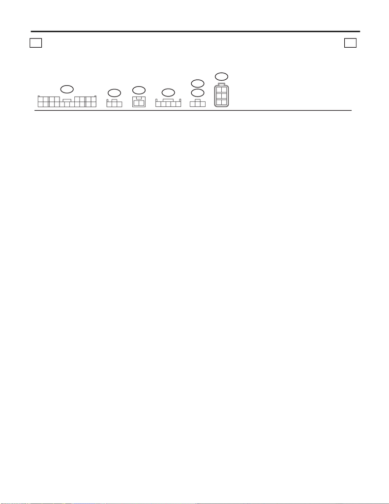

WI-294

Keyless Access System

WIRING SYSTEM

WI-45449

2j 2j

R296

3

421

5

R298

R297

123

R186

123

R294

21

(BR)

(B)

R82

1

9

234 5678

10 11 12 14 15 16 17 18 1913

R299

56

34

12

LIST OF CONNECTORS